# OPTIMASI PORTOFOLIO BERBASIS MODEL MARKOWITZ MENGGUNAKAN METODE VARIATIONAL QUANTUM EIGENSOLVER

Tugas Akhir SF234801

Putra Naufal Tabassam

NRP : 5001221120

Pembimbing : Dr. Heru Sukamto, M.Si.

Ko-Pembimbing : Dr. Gagus K. Sunnardianto

Departemen Fisika, Institut Teknologi Sepuluh Nopember

### ⚠️ DISCLAIMER ⚠️

Materi yang disajikan dalam presentasi ini murni untuk **tujuan akademis dan penelitian keilmuan**. Presentasi ini **bukan** merupakan bentuk rekomendasi, ajakan, maupun nasihat finansial profesional.

Audiens diharapkan untuk selalu bertindak bijak, melakukan riset mandiri (*Do Your Own Research*), dan bertanggung jawab penuh atas segala bentuk keputusan investasi serta risiko pertumbuhan modalnya masing-masing.

# Fase Latar Belakang

## Tokoh Penting yang Terlibat

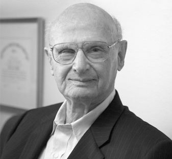

Harry Markowitz

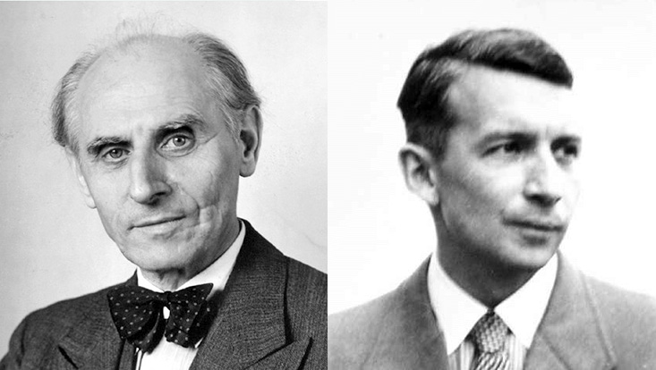

Wilhelm Lenz & Ernst Ising

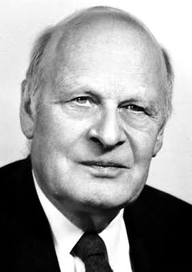

Lars Onsager

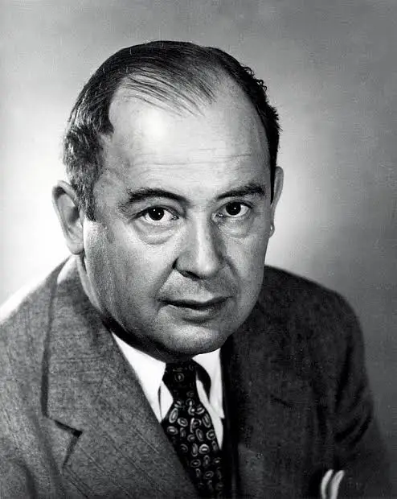

John von Neumann

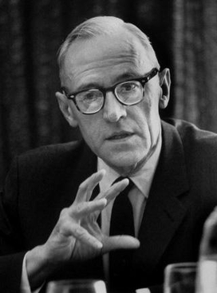

Oskar Morgenstern

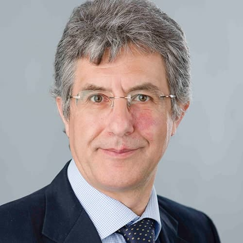

Rosario N. Mantegna

## Penelitian Terdahulu dan Research Gap

Penelitian Terdahulu

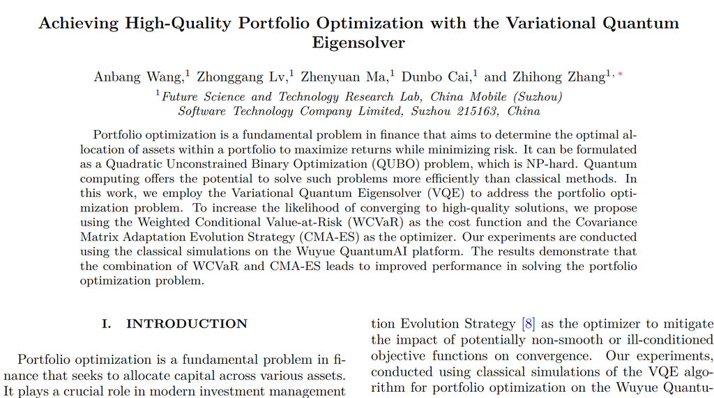

**Wang dkk. (2025)**

VQE + WCVaR + CMA-ES

Stabilisasi konvergensi energi.

➜

Penelitian Terdahulu

[figure not shown]

**Wei dkk. (2025)**

Quantum-Classical Hybrid Annealing

Memecah masalah QUBO kompleks menjadi submasalah.

➜

Research Gap

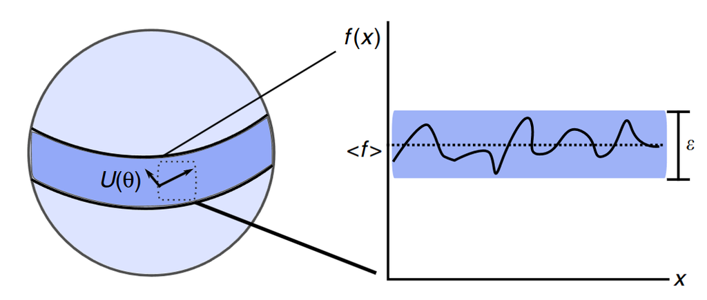

Masih bergantung pada

**inisialisasi acak**

yang rentan mengalami

**Barren Plateau**

Solusi

[figure not shown]

Menggunakan **Nash Equilibrium** sebagai **Warm-Start Initialization**

Sumber: Wang *et al.* (2025); Wei *et al.* (2025)

## Ekonomi dan Investasi

[figure not shown]

[figure not shown]

Inflasi & Guncangan Ekonomi

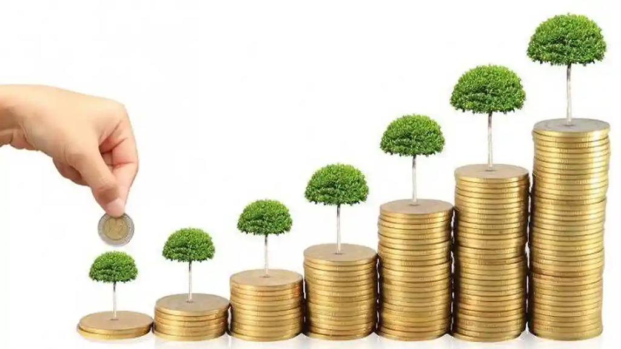

Urgensi Investasi

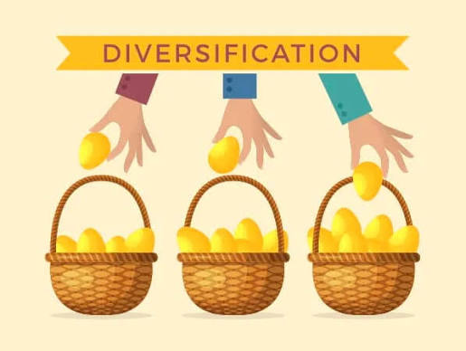

Diversifikasi Portofolio

## Analisis Fundamental dan Teknikal

**Analisis Fundamental**

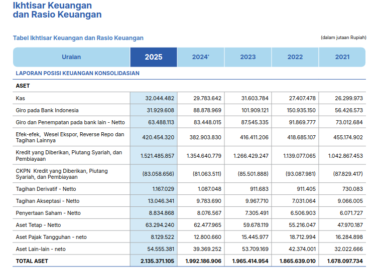

- Ekonometrik Perusahaan
- Kesehatan Fiskal
- Sentimen Pasar

**Analisis Teknikal**

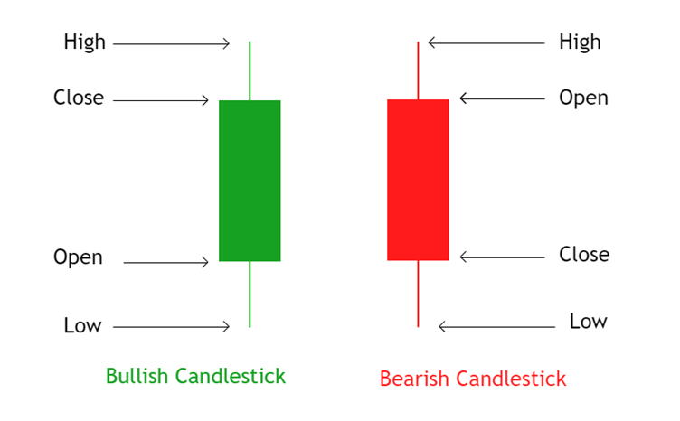

*Candlestick*

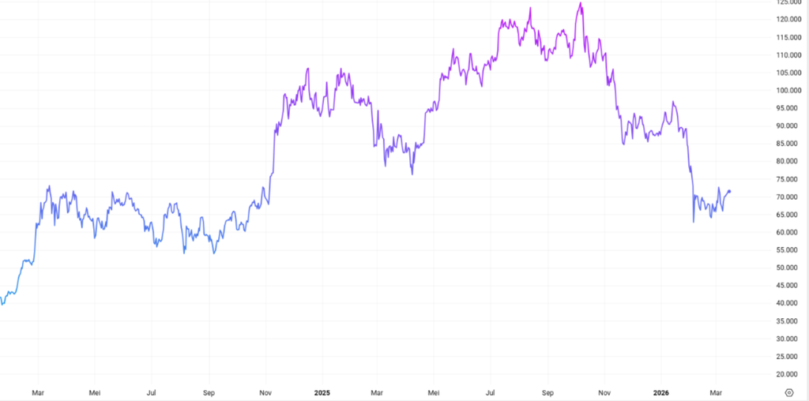

*Price Chart*

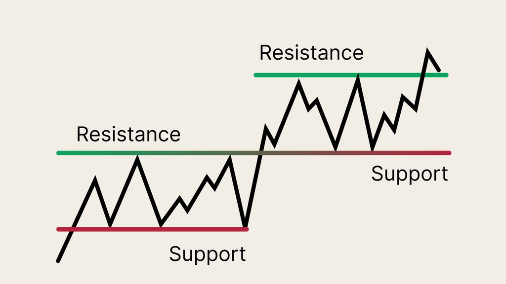

*Support & Resistance*

- Representasi Psikologi Kolektif dari Agen Pasar

## Analisis Kuantitatif

- **Simple Return ($R$):**
  $$R_t = \frac{P_t - P_{t-1}}{P_{t-1}}$$
- **Expected Return ($\bar{R}$):**
  $$\bar{R} = \frac{1}{n} \sum_{t=1}^n R_t$$
- **Variance ($\sigma^2$):**
  $$\sigma^2 = \frac{1}{n-1} \sum_{t=1}^n (R_t - \bar{R})^2$$
- **Covariance ($\sigma_{ij}$):**
  $$\sigma_{ij} = \frac{1}{n-1} \sum_{t=1}^n (R_{i,t} - \bar{R}_i)(R_{j,t} - \bar{R}_j)$$
- **Log Return ($r$):**
  $$r_t = \ln\left(\frac{P_t}{P_{t-1}}\right)$$
- **Expected Return ($\bar{r}$):**
  $$\bar{r} = \frac{1}{n} \sum_{t=1}^n r_t$$
- **Variance ($\sigma^2$):**
  $$\sigma^2 = \frac{1}{n-1} \sum_{t=1}^n (r_t - \bar{r})^2$$
- **Covariance ($\sigma_{ij}$):**
  $$\sigma_{ij} = \frac{1}{n-1} \sum_{t=1}^n (r_{i,t} - \bar{r}_i)(r_{j,t} - \bar{r}_j)$$

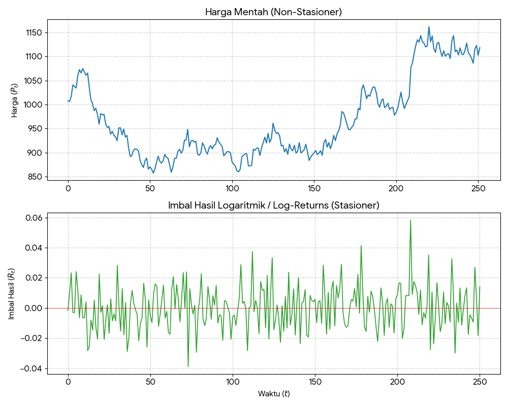

Transformasi pergerakan harga saham.

- $P_t$: Harga pada waktu $t$

## Model Markowitz

- Rumus Utama
- Penurunan Rumus
- **Mean-Variance:**
  $$\mathcal{L}(\mathbf{\omega}) = \sum_{i,j} \sigma_{ij} \omega_i \omega_j - \lambda \sum_i \mu_i \omega_i$$
- **Binerisasi:**
  $$\mathcal{L}(\mathbf{x}) = \sum_{i,j} \sigma_{ij} \frac{x_i x_j}{K^2} - \lambda \sum_i \mu_i \frac{x_i}{K}$$
- $\mu_i$: Imbal hasil rata-rata aset ke-$i$
- $\sigma_{ij}$: Kovarians antara aset $i$ dan $j$
- $\omega_i$: Proporsi bobot kontinu aset ke-$i$
- $\lambda$: Parameter toleransi risiko

Contoh Alokasi Modal (Rp 10 Juta)

```
%%{init: {"themeVariables": {"pieSectionTextSize": "36px", "pieLegendTextSize": "20px"}}}%%
pie
  "Cash" : 40
  "BBCA" : 30
  "ADRO" : 30
```

| Aset | Persentase | Nominal |
| --- | --- | --- |
| **Cash** | 40% | Rp 4.000.000 |
| **BBCA** | 30% | Rp 3.000.000 |
| **ADRO** | 30% | Rp 3.000.000 |

**Langkah 1 — Formulasi Lagrangian Kontinu (Markowitz):**

Fungsi biaya Markowitz dalam domain bobot $\omega_i$:

$$\mathcal{L}(\mathbf{\omega}) = \sum_{i,j} \sigma_{ij} \omega_i \omega_j - \lambda \sum_i \mu_i \omega_i$$

dengan syarat $\sum_i \omega_i = 1$ dan $\omega_i \geq 0$.

**Langkah 2 — Substitusi Variabel Biner:**

Variabel bobot kontinu $\omega_i$ diubah menjadi variabel biner $x_i \in \{0, 1\}$ melalui hubungan:

$$\omega_i = \frac{x_i}{K}$$

di mana $K$ adalah jumlah aset yang dipilih dari total $N$ kandidat.

**Langkah 3 — Substitusi ke Lagrangian:**

Substitusi $\omega_i = x_i/K$ ke dalam fungsi Lagrangian:

$$\mathcal{L}(\mathbf{x}) = \sum_{i,j} \sigma_{ij} \frac{x_i}{K} \frac{x_j}{K} - \lambda \sum_i \mu_i \frac{x_i}{K}$$

$$\therefore \mathcal{L}(\mathbf{x}) = \sum_{i,j} \sigma_{ij} \frac{x_i x_j}{K^2} - \lambda \sum_i \mu_i \frac{x_i}{K}$$

Nilai $x_i = 1$ merepresentasikan **beli**, sedangkan $x_i = 0$ merepresentasikan **tidak membeli**.

| Simbol | Domain Kontinu | Domain Biner |
| --- | --- | --- |
| Variabel keputusan | $\omega_i \in [0, 1]$ | $x_i \in \{0, 1\}$ |
| Kendala | $\sum \omega_i = 1$ | $\sum x_i = K$ |

## Metode Evaluasi Performa (Backtesting)

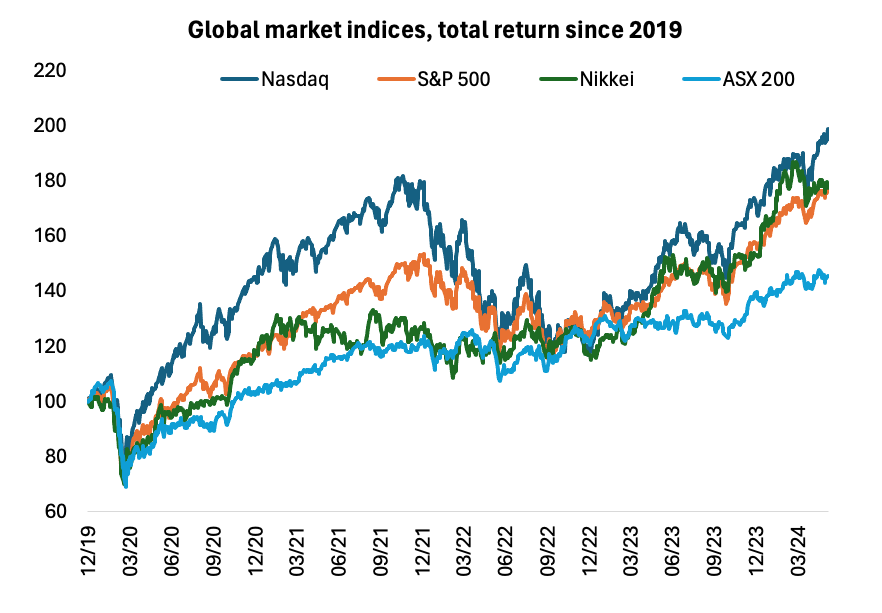

Simulasi riwayat harga dan rebalance portofolio secara periodik

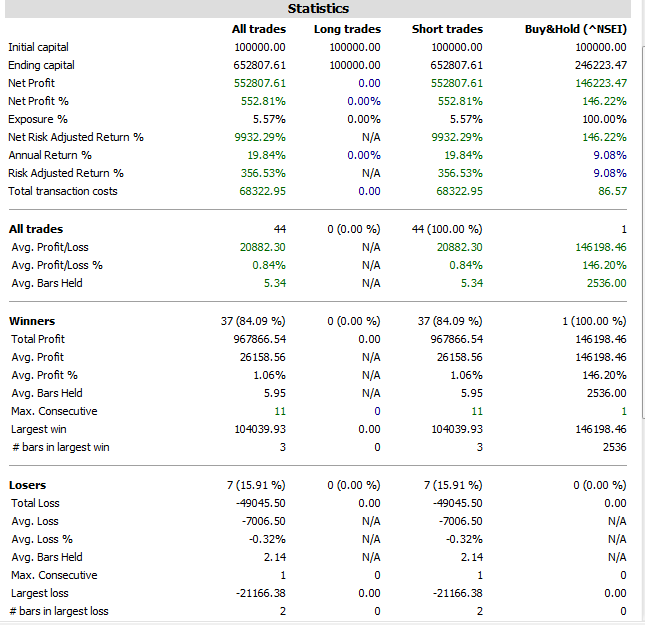

Data backtesting pada sebuah strategi trading

## Tujuan Penelitian

1. Menganalisis formulasi bias aset sebagai parameter medan lokal ($h_i$) dan interaksi antar aset sebagai koefisien kopling ($J_{ij}$) melalui pendekatan fungsi potensial dalam sistem Hamiltonian berbasis *Exact Potential Game* (EPG).
2. Mengevaluasi kontribusi strategi *warm-start* berbasis *Nash Equilibrium* dalam meningkatkan efisiensi pencarian solusi optimal pada algoritma VQE.
3. Menguji kapabilitas algoritma VQE yang menggunakan optimasi SPSA dan *Ansatz EfficientSU(2)* untuk menghasilkan keputusan alokasi aset yang optimal dalam kondisi pasar yang kompleks.

## Batasan Masalah (1/2)

1. Portofolio yang dianalisis dibatasi pada pemilihan 1 aset dari 2 pilihan aset pada sistem $N=2$ dan 2 aset dari 4 pilihan aset pada sistem $N=4$.
2. Model permainan yang digunakan adalah skema *non zero-sum game* dalam kerangka *Exact Potential Game*.
3. Simulasi dan implementasi algoritma dilakukan menggunakan simulator *Pennylane* tanpa mempertimbangkan *noise*.

## Batasan Masalah (2/2)

4. Tugas akhir ini hanya merupakan *proof-of-concept* dari implementasi *warm-start* ekuilibrium Nash terhadap performa algoritma VQE dalam menemukan solusi *ground state* pada model portofolio hibrida.
5. Analisis Entropi Von Neumann dibatasi sebagai indikator perubahan distribusi probabilitas keadaan kuantum selama proses optimasi VQE dan tidak digunakan sebagai kajian mendalam mengenai sifat keterbelitan dari *ansatz*.
6. Analisis berfokus pada pengaruh *warm-start* ekuilibrium Nash terhadap proses optimasi VQE, bukan untuk membuktikan keunggulan komputasi kuantum terhadap metode klasik.

# Fase Metodologi

## Diagram Alir Utama

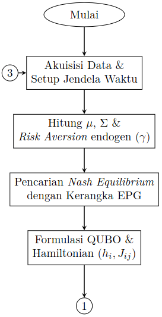

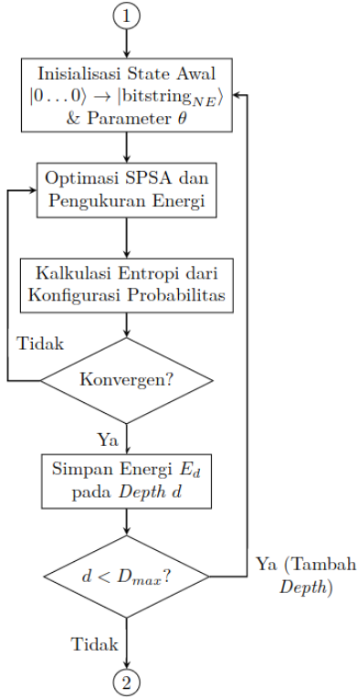

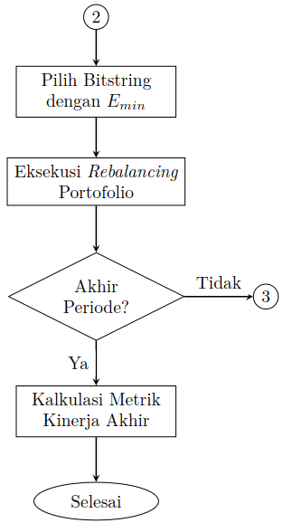

## Teori Permainan

- **Teori Permainan:** Cabang matematika terapan yang mengkaji bagaimana agen rasional membuat keputusan strategis di bawah ketergantungan tindakan agen yang lain.
- **Komponen Utama:** Agen (Pemain), Himpunan Strategi, dan Fungsi Utilitas (*Payoff*).
- **Nash Equilibrium:** Kondisi paling stabil di mana tidak ada satu pun agen yang bisa meningkatkan utilitasnya dengan mengubah strateginya sendiri secara sepihak.

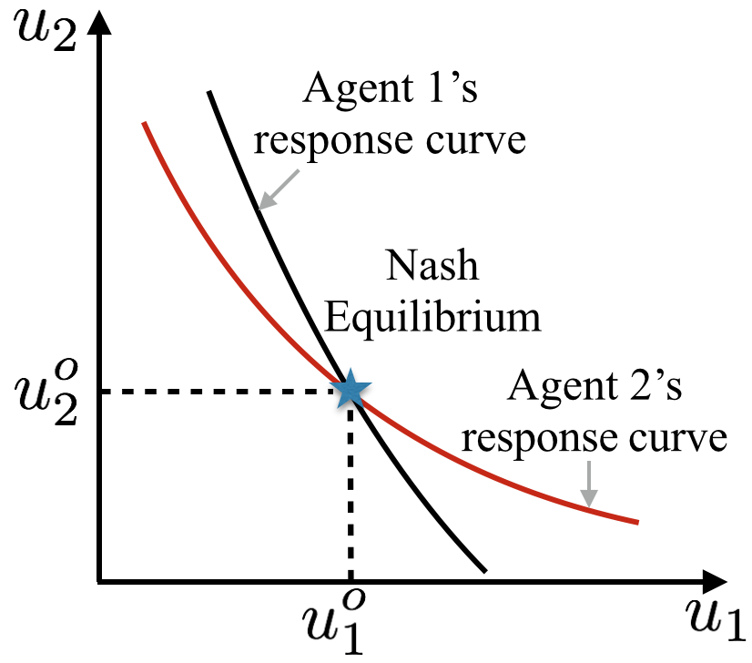

*Nash Equilibrium*

## Jenis-Jenis Permainan (*Game Types*)

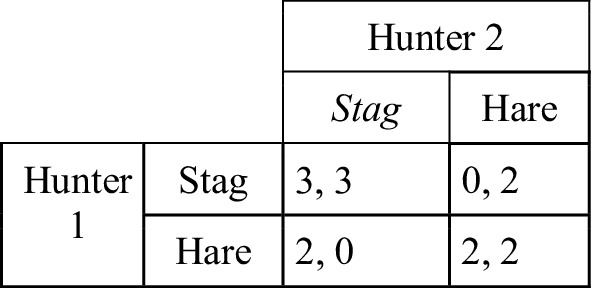

*Stag Hunt*

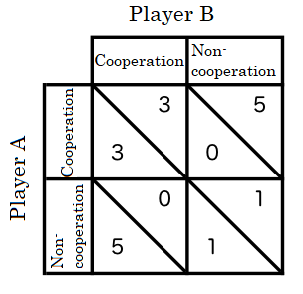

*Prisoner’s Dilemma*

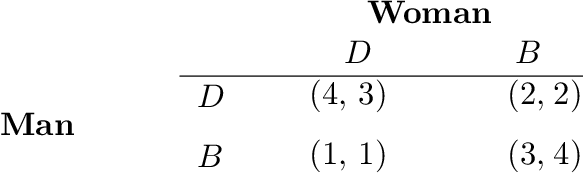

*Battle of the Sexes*

## Exact Potential Game (EPG)

*Referensi: Monderer & Shapley (1996)*

- **Definisi:** Model permainan yang memiliki fungsi potensial global ($\Phi$), di mana setiap perubahan utilitas individu akibat perubahan strategi sepenuhnya tercermin oleh perubahan nilai $\Phi$.
- **Makna “Potensial” & “Global”:**
  - **Potensial:** Sistem agen berdinamika menuju nilai ekuilibrium (maksimalisasi utilitas), yang secara fundamental ekuivalen dengan prinsip minimisasi energi ($H = -\Phi$) dalam fisika fisis.
  - **Global:** $\Phi$ merangkum seluruh utilitas individu ke dalam satu fungsi skalar tunggal untuk merepresentasikan kualitas konfigurasi strategi permainan secara keseluruhan.
- **Kondisi *Nash Equilibrium*:** Perubahan utilitas lokal ($\Delta u_i$) sebanding persis dengan perubahan potensial global ($\Delta \Phi$).
  $$\Delta \Phi = \Phi(s_i', s_{-i}) - \Phi(s_i, s_{-i}) = u_i(s_i', s_{-i}) - u_i(s_i, s_{-i})$$
- Dinamika sistem akan terhenti dan mencapai *Nash Equilibrium* ketika tidak ada lagi strategi yang menghasilkan peningkatan potensial ($\Delta \Phi < 0$).

## EPG pada Alokasi Portofolio

- Rumus Utama
- Penurunan Rumus
- Contoh Numerik
- Transformasi persamaan utilitas Markowitz biner menjadi fungsi potensial global EPG:
  $$\Phi(\mathbf{x}) = \sum_{l=1}^N \mu_l \frac{x_l}{K} - \frac{\gamma}{2}\sum_{i=1}^N\sum_{j=1}^N \sigma_{ij} \frac{x_i}{K} \frac{x_j}{K}$$
- dengan $\gamma$ mendefinisikan faktor penghindaran risiko (*risk aversion*) pada fungsi utilitas agen.

**Penurunan: Dari Model Markowitz Biner ke Fungsi Potensial EPG**

**Langkah 1 — Lagrangian Biner Markowitz:**

Dari transformasi $\omega_i = x_i/K$, diperoleh fungsi Lagrangian biner:

$$\mathcal{L}(\mathbf{x}) = \sum_{i,j} \sigma_{ij} \frac{x_i x_j}{K^2} - \lambda \sum_i \mu_i \frac{x_i}{K}$$

**Langkah 2 — Konversi ke Fungsi Utilitas:**

Definisikan faktor penghindaran risiko $\gamma = 2/\lambda$, sehingga:

$$U(\mathbf{x}) = - \frac{1}{\lambda} \mathcal{L}(\mathbf{x})$$

$$U(\mathbf{x}) = \sum_i \frac{\mu_i}{K} x_i - \frac{\gamma}{2K^2} \sum_{i,j} \sigma_{ij} x_i x_j$$

**Langkah 3 — Utilitas Individu Agen ke-$i$:**

Jika varians dipisah dari matriks kovarians:

$$u_i(\mathbf{x}) = \frac{\mu_i}{K} x_i - \frac{\gamma}{2K^2} x_i \left( \sigma_{ii} + \sum_{j \neq i} \sigma_{ij} x_j \right)$$

**Langkah 4 — Fungsi Potensial Global $\Phi$:**

Dari utilitas sistem, fungsi potensial EPG:

$$\Phi(\mathbf{x}) = \sum_{l=1}^N \mu_l \frac{x_l}{K} - \frac{\gamma}{2}\sum_{i=1}^N\sum_{j=1}^N \sigma_{ij} \frac{x_i}{K} \frac{x_j}{K}$$

**Langkah 5 — Dekomposisi untuk Verifikasi $\Delta u_i = \Delta \Phi$:**

Dekomposisi suku yang mengandung $x_i$ (dengan $x_i^2 = x_i$):

$$\Phi(\mathbf{x}) = \frac{\mu_i}{K}x_i - \frac{\gamma}{2} \left( \frac{\sigma_{ii}}{K^2}x_i + \frac{1}{K^2}x_i \sum_{j \neq i} \sigma_{ij}x_j \right) + \underbrace{\sum_{l \neq i} \frac{\mu_l}{K}x_l - \frac{\gamma}{2} \sum_{l \neq i} \sum_{m \neq i} \frac{\sigma_{lm}}{K^2}x_l x_m}_{\text{tidak bergantung pada } x_i}$$

**Langkah 6 — Insentif Marginal:**

$$\Delta \Phi = \Phi(1, \mathbf{x}_{-i}) - \Phi(0, \mathbf{x}_{-i}) = \frac{\mu_i}{K} - \frac{\gamma \sigma_{ii}}{2K^2} - \frac{\gamma}{K^2} \sum_{j \neq i} \sigma_{ij} x_j$$

**Langkah 7 — Risk Aversion Endogen:**

$$\gamma = \frac{1}{1 + e^{(\bar{\mu}_l/\bar{\sigma}_l)}}$$

dengan $\bar{\mu}_l$ dan $\bar{\sigma}_l$ dari *log returns*.

**Contoh Pencarian *Nash Equilibrium* dengan SBR**

Misalkan terdapat tiga aset dengan parameter:

$$\gamma = 1,\qquad \mu = \begin{bmatrix} 12\\ 11\\ 8 \end{bmatrix},\qquad \Sigma=\begin{bmatrix} 10 & 8 & 2\\ 8 & 10 & -2\\ 2 & -2 & 10 \end{bmatrix}$$

dan jumlah aset yang harus dipilih adalah:

$$K=2$$

Fungsi potensial didefinisikan sebagai:

$$\Phi(x)=\frac{1}{K}\sum_i\mu_i x_i -\frac{\gamma}{2K^2}\sum_{i,j}\Sigma_{ij}x_ix_j$$

**Langkah 1 — Inisialisasi**

Sesuai algoritma:

$$x=(1,1,0)$$

sehingga:

$$S_{in}=\{1,2\},\qquad S_{out}=\{3\}$$

Nilai fungsi potensial awal adalah:

$$\Phi(110)=\frac{12+11}{2}-\frac{1}{8}(10+10+8+8)=7$$

**Langkah 2 — Evaluasi Kandidat Swap**

**Swap (1,3)**

$$110\rightarrow 011$$

$$\Phi(011)=\frac{11+8}{2}-\frac18(10+10-2-2)=7.5$$

Karena:

$$7.5>7$$

swap **diterima**.

**Langkah 3 — Pembaruan Sekuensial**

Bitstring diperbarui menjadi:

$$x=(0,1,1)$$

Sekarang:

$$S_{in}=\{2,3\},\qquad S_{out}=\{1\}$$

Kandidat berikutnya:

$$011\rightarrow101$$

Diperoleh:

$$\Phi(101)=\frac{12+8}{2}-\frac18(10+10+2+2)=7$$

Karena:

$$7<7.5$$

swap **ditolak**.

**Langkah 4 — Terminasi**

Tidak terdapat lagi *swap* yang meningkatkan nilai fungsi potensial:

$$\Phi' \le \Phi$$

Oleh karena itu algoritma berhenti dan menghasilkan:

$$\boxed{x=(0,1,1)}$$

sebagai kandidat *Nash Equilibrium* yang akan digunakan sebagai strategi *warm-start* bagi VQE.

## Transformasi EPG ke Model Ising

- Transformasi QUBO
- Penurunan Rumus

**Fungsi Energi dari Potensial (Markowitz Biner):**
$$E(\mathbf{x}) = \frac{\gamma}{2K^2}\sum_{i=1}^N\sum_{j=1}^N \sigma_{ij} x_i x_j - \sum_{i=1}^N \frac{\mu_i}{K} x_i$$

**Penurunan: Dari Fungsi Potensial Game ke Hamiltonian Ising**

**Langkah 1 — Fungsi Energi dari Potensial:**

Konversi dari maksimasi potensial ke minimasi energi:

$$E(\mathbf{x}) = -\Phi(\mathbf{x})$$

Substitusi $\Phi$ dari fungsi potensial Markowitz:

$$E(\mathbf{x}) = \frac{\gamma}{2K^2}\sum_{i=1}^N\sum_{j=1}^N \sigma_{ij} x_i x_j - \sum_{i=1}^N \frac{\mu_i}{K} x_i$$

**Langkah 2 — Dekomposisi dengan $x_i^2 = x_i$:**

$$E(\mathbf{x}) = \frac{\gamma}{2K^2}\left(\sum_{i=1}^N\sigma_{ii} x_i^2 + \sum_{i\ne j}\sigma_{ij} x_ix_j\right) -\sum_{i=1}^N \frac{\mu_i}{K} x_i$$

$$= \frac{\gamma}{2K^2}\sum_{i=1}^N\sigma_{ii} x_i + \frac{\gamma}{2K^2}\sum_{i\ne j}\sigma_{ij} x_ix_j - \sum_{i=1}^N \frac{\mu_i}{K} x_i$$

$$\therefore E(\mathbf{x}) = \sum_{i=1}^N\left(\frac{\gamma \sigma_{ii}}{2K^2} - \frac{\mu_i}{K}\right)x_i + \sum_{i\ne j}\frac{\gamma \sigma_{ij}}{2K^2} x_ix_j$$

**Langkah 3 — Penambahan Fungsi Penalti:**

Penalti kuadratik untuk memenuhi kendala $\sum x_i = K$:

$$P(\mathbf{x}) = A\left(\sum_{i=1}^N x_i - K\right)^2$$

Penjabaran:

$$P(\mathbf{x}) = A\sum_{i=1}^N x_i^2 + A\sum_{i\ne j} x_ix_j - 2AK\sum_{i=1}^N x_i + AK^2$$

**Langkah 4 — Energi Total (QUBO):**

$$E_{total}(\mathbf{x}) = E(\mathbf{x}) + P(\mathbf{x})$$

$$\therefore E_{total}(\mathbf{x}) = \sum_i \left(\frac{\gamma \sigma_{ii}}{2K^2} + A - \frac{\mu_i}{K} - 2AK\right)x_i + \sum_{i\ne j}\left(\frac{\gamma \sigma_{ij}}{2K^2} + A\right) x_ix_j + AK^2$$

**Langkah 5 — Notasi Koefisien QUBO:**

$$Q_{ii} = \frac{\gamma \sigma_{ii}}{2K^2}+A-\frac{\mu_i}{K}-2AK$$

$$Q_{ij} = \frac{\gamma \sigma_{ij}}{2K^2}+A$$

Sehingga:

$$E_{total}(\mathbf{x}) = \sum_i Q_{ii} x_i + \sum_{i\ne j} Q_{ij} x_ix_j + AK^2$$

**Langkah 6 — Transformasi Affine ke Domain Spin:**

Pemetaan biner $x_i \in \{0, 1\}$ ke *spin* $s_i \in \{-1, 1\}$:

$$x_i = \frac{(1 - s_i)}{2}, \quad x_ix_j = \frac{(1-s_i)(1-s_j)}{4}$$

Substitusi:

$$E_{total}(\mathbf{s}) = \sum_i Q_{ii} \frac{1-s_i}{2} + \sum_{i\ne j} Q_{ij} \frac{1 - s_i - s_j + s_is_j}{4} + AK^2$$

$$\therefore E_{total}(\mathbf{s}) = \sum_i \left(- \frac{Q_{ii}}{2} - \sum_{j \neq i} \frac{Q_{ij}}{2}\right) s_i + \sum_{i\ne j} \frac{Q_{ij}}{4} s_i s_j + \left(\sum_i \frac{Q_{ii}}{2} + \sum_{i\ne j} \frac{Q_{ij}}{4} + AK^2\right)$$

**Langkah 7 — Identifikasi Parameter Hamiltonian:**

| Parameter | Definisi | Makna Fisis |
| --- | --- | --- |
| $h_i$ | $- \frac{Q_{ii}}{2} - \sum_{j \neq i} \frac{Q_{ij}}{2}$ | Medan bias lokal |
| $J_{ij}$ | $\frac{Q_{ij}}{4}$ | Kopling antar *spin* |
| $C$ | $\sum_i \frac{Q_{ii}}{2} + \sum_{i\ne j} \frac{Q_{ij}}{4} + AK^2$ | Konstanta energi |

**Hasil Akhir — Hamiltonian Ising:**

## Analogi Keputusan Investasi dan Ising

*Referensi: Lucas (2014); Galam & Walliser (2010)*

Memetakan fungsi biaya portofolio ke dalam struktur Hamiltonian sistem fisik.

| Komponen Investasi | Analogi Sistem Ising (Fisika) |
| --- | --- |
| Aset Keuangan | Partikel *Spin* (Atas/Bawah) |
| Keputusan Investasi (Beli/Jual) | Orientasi *Spin* (+1 / -1) |
| Tren/Ekspektasi Pasar | Medan Magnet Lokal ($h_i$) |
| Korelasi/Kovariansi Antar Aset | Interaksi Kopling Antar *Spin* ($J_{ij}$) |
| Alokasi Modal Paling Efisien | Konfigurasi Energi Terendah (*Ground State*) |

## Bit Klasik vs Qubit Kuantum

**Bit Klasik:**

- Unit informasi fundamental komputer konvensional.
- Hanya bernilai 0 atau 1.
- 0 (tidak ada arus listrik), 1 (ada arus listrik).

0

⇄

1

Transistor: 1 dan 0 secara bergantian

**Qubit Kuantum:**

- Unit informasi fundamental komputer kuantum.
- Memanfaatkan prinsip Superposisi: 0, 1, atau kombinasi linear keduanya.
  $$|\psi\rangle = \alpha|0\rangle + \beta|1\rangle$$

0 & 1 Bersamaan

Qubit: 1 dan 0 secara bersamaan

## Representasi & Geometri Qubit

- **Basis Komputasi:**
  $$|0\rangle = \begin{pmatrix} 1 \\ 0 \end{pmatrix}, \quad |1\rangle = \begin{pmatrix} 0 \\ 1 \end{pmatrix}$$
- **Syarat Normalisasi:** Total probabilitas harus bernilai 1 ($|\alpha|^2 + |\beta|^2 = 1$).
- Dua parameter sudut:
  - $\theta$ (Polar): Menentukan probabilitas $|0\rangle$ vs $|1\rangle$.
  - $\phi$ (Azimuthal): Menentukan fase kuantum.
- Fungsi gelombang qubit:
  $$|\psi\rangle = \cos\frac{\theta}{2}|0\rangle + e^{i\phi}\sin\frac{\theta}{2}|1\rangle$$

[interactive chart not shown]

Interaktif: Atur parameter & putar objek 3D

## Desain Sirkuit Kuantum

- Arsitektur Sirkuit
- Gerbang Rotasi Total
- Gerbang CNOT Total

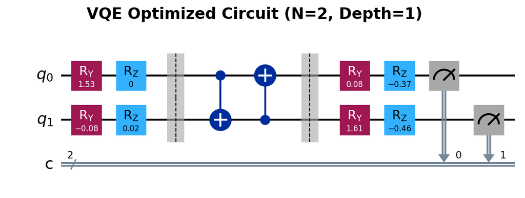

Arsitektur *Hardware-Efficient Ansatz* dengan *depth* $D=1$

**Matriks Rotasi $U_q(\theta)$ untuk 2 Qubit**

Berdasarkan definisi gerbang rotasi $R_y(\theta)$ dan $R_z(\theta)$:
$$\begin{align}
U_{1q}(\theta) &= R_z(\theta_{1z}) R_y(\theta_{1y}) \\
&= \begin{pmatrix} e^{-i\theta_{1z}/2} & 0 \\ 0 & e^{i\theta_{1z}/2} \end{pmatrix} \begin{pmatrix} \cos(\theta_{1y}/2) & -\sin(\theta_{1y}/2) \\ \sin(\theta_{1y}/2) & \cos(\theta_{1y}/2) \end{pmatrix} \\
&= \begin{pmatrix} e^{-i\theta_{1z}/2} \cos(\theta_{1y}/2) & -e^{-i\theta_{1z}/2} \sin(\theta_{1y}/2) \\ e^{i\theta_{1z}/2} \sin(\theta_{1y}/2) & e^{i\theta_{1z}/2} \cos(\theta_{1y}/2) \end{pmatrix}
\end{align}$$

**Matriks Gerbang Keterbelitan ($U_{ent}$) untuk 2 Qubit**

Untuk lapisan keterbelitan, secara umum didefinisikan:
$$U_{ent} = CNOT_{(N-1,0)} \prod_{q=0}^{N-2} CNOT_{(q,q+1)}$$

Untuk sistem 2 qubit, hal ini mereduksi menjadi:
$$U_{ent} = CNOT_{(1,0)} \cdot CNOT_{(0,1)}$$

di mana matriks untuk masing-masing gerbang adalah:
$$CNOT_{(1,0)} = \begin{pmatrix} 1 & 0 & 0 & 0 \\ 0 & 0 & 0 & 1 \\ 0 & 0 & 1 & 0 \\ 0 & 1 & 0 & 0 \end{pmatrix} \quad CNOT_{(0,1)} = \begin{pmatrix} 1 & 0 & 0 & 0 \\ 0 & 1 & 0 & 0 \\ 0 & 0 & 0 & 1 \\ 0 & 0 & 1 & 0 \end{pmatrix}$$

Sehingga matriks total keterbelitannya adalah:
$$U_{ent} = \begin{pmatrix} 1 & 0 & 0 & 0 \\ 0 & 0 & 0 & 1 \\ 0 & 0 & 1 & 0 \\ 0 & 1 & 0 & 0 \end{pmatrix} \cdot \begin{pmatrix} 1 & 0 & 0 & 0 \\ 0 & 1 & 0 & 0 \\ 0 & 0 & 0 & 1 \\ 0 & 0 & 1 & 0 \end{pmatrix} = \begin{pmatrix} 1 & 0 & 0 & 0 \\ 0 & 0 & 1 & 0 \\ 0 & 0 & 0 & 1 \\ 0 & 1 & 0 & 0 \end{pmatrix}$$

## Optimizer SPSA

*Referensi: Spall (1998)*

- Rumus Utama
- Penurunan Rumus

**SPSA (Simultaneous Perturbation Stochastic Approximation)**

- **Inovasi:** Mengestimasi gradien *seluruh* parameter secara simultan hanya menggunakan dua pengukuran (satu vektor perturbasi acak $\Delta$).
  $$\hat{g}_k = \frac{E(\theta_k + c_k \Delta_k) - E(\theta_k - c_k \Delta_k)}{2 c_k \Delta_k}$$
- Dengan ekspektasi estimasi gradien yang terbukti ekuivalen dengan gradien eksak:
  $$\mathbb{E} \left[ \hat{g}_k \right] = \nabla E(\theta_k)$$

**Penurunan: Estimator Gradien SPSA**

**Langkah 1 — Vektor Perturbasi Acak:**

$$\Delta_k = (\Delta_{k,1}, \Delta_{k,2}, \ldots, \Delta_{k,p}), \quad \Delta_{k,i} = \begin{cases} +1, & P = 1/2 \\ -1, & P = 1/2 \end{cases}$$

Setiap komponen mengikuti distribusi *Rademacher*.

**Langkah 2 — Evaluasi Fungsi Biaya:**

$$E_+ = E(\boldsymbol{\theta}_k + c_k\Delta_k), \quad E_- = E(\boldsymbol{\theta}_k - c_k\Delta_k)$$

**Langkah 3 — Ekspansi Taylor:**

$$E_+ = E(\boldsymbol{\theta}_k) + c_k \sum_{j=1}^{p} \Delta_j \frac{\partial E}{\partial \theta_j} + \frac{1}{2}c_k^2 \sum_{j=1}^{p} \Delta_j^2 \frac{\partial^2 E}{\partial \theta_j^2} + O(c_k^3)$$

$$E_- = E(\boldsymbol{\theta}_k) - c_k \sum_{j=1}^{p} \Delta_j \frac{\partial E}{\partial \theta_j} + \frac{1}{2}c_k^2 \sum_{j=1}^{p} \Delta_j^2 \frac{\partial^2 E}{\partial \theta_j^2} + O(c_k^3)$$

**Langkah 4 — Selisih (suku genap saling hilang):**

$$E_+ - E_- = 2c_k \sum_{j=1}^{p} \Delta_j \frac{\partial E}{\partial \theta_j} + O(c_k^3)$$

**Langkah 5 — Estimator Gradien:**

$$\hat{g}_i = \frac{E_+ - E_-}{2c_k \Delta_i} = \frac{\partial E}{\partial \theta_i} + \sum_{j \neq i} \frac{\Delta_j}{\Delta_i} \frac{\partial E}{\partial \theta_j}$$

**Langkah 6 — Bukti Tak-Bias:**

Karena $\Delta_j$ independen dan $\mathbb{E}\left[\frac{\Delta_j}{\Delta_i}\right] = 0$ untuk $j \neq i$:

$$\mathbb{E}[\hat{g}_i] = \frac{\partial E}{\partial \theta_i} + \sum_{j \neq i} \underbrace{\mathbb{E}\left[\frac{\Delta_j}{\Delta_i}\right]}_{= 0} \frac{\partial E}{\partial \theta_j} = \frac{\partial E}{\partial \theta_i}$$

$$\therefore \boxed{\mathbb{E}[\hat{\mathbf{g}}_k] = \nabla E(\boldsymbol{\theta}_k)}$$

**Langkah 7 — Pembaruan Parameter & Peluruhan:**

$$\boldsymbol{\theta}_{k+1} = \boldsymbol{\theta}_k - a_k \hat{\mathbf{g}}_k$$

dengan hiperparameter peluruhan:

$$a_k = \frac{a}{(A+k+1)^\alpha}, \quad c_k = \frac{c}{(k+1)^\gamma}$$

dengan nilai $\alpha = 0.602$ dan $\gamma = 0.101$.

## Evaluasi Distribusi Probabilitas (Entropi)

$$S(\rho) = -\sum_i \lambda_i \log_2 (\lambda_i)$$

**Sistem $N=2$**

| Parameter | Nilai |
| --- | --- |
| Probabilitas mayoritas ($p_1$) | $0{,}98$ |
| Sisa probabilitas ($p_\text{rest}$) | $0{,}02$ |

**Kalkulasi:**
$$S = -(0{,}98 \cdot \log_2(0{,}98) + 0{,}02 \cdot \log_2(0{,}02)) \approx 0{,}1414 \text{ bit}$$

**Sistem $N=4$**

| Parameter | Nilai |
| --- | --- |
| Prob. Optimal ($p_1$) | $0{,}94$ |
| Prob. Alternatif ($p_2, p_3, p_4$) | @ $0{,}02$ |

**Kalkulasi:**
$$S = -\left(0{,}94 \log_2(0{,}94) + 3 \times (0{,}02 \log_2(0{,}02))\right) \approx 0{,}4225 \text{ bit}$$

## Algoritma Evaluasi: *Backtesting*

**Skema *Rolling Window Backtesting*:**

```
Procedure BacktestLoop(Data, K)
  1. For t in Timeline:
  2.    mu, Sigma, gamma <- DataPreprocessing(t)
  3.    H <- BuildHamiltonian(mu, Sigma, gamma)
  4.    x_NE <- NashSBR(H) // Pencarian Titik Ekuilibrium
  5.    x_best_t <- AdaptiveVQE(H, x_NE) // GT-VQE Optimization
  6.    R_t <- ExecuteRebalance(x_best_t) // Pindah Aset Berdasarkan Sinyal
  7. Return PerformanceMetrics
EndProcedure
```

- Siklus dieksekusi secara iteratif melalui jendela waktu berjalan (*sliding window*).

## Perhitungan Metrik Performa Finansial

- Metrik Finansial
- Optimasi Klasik SLSQP
- Contoh Numerik
- **Return Kumulatif:** Mengukur total pertumbuhan persentase modal selama periode simulasi.
  $$R_{cum} = \prod_{t=1}^T (1 + R_t) - 1$$
- **Sharpe Ratio:** Rasio antara *return* ekspektasi terhadap risiko volatilitas portofolio ($\sigma_p$).
  $$\text{Sharpe} = \frac{\bar{R}_p - R_f}{\sigma_p}$$

  $\bar{R}_p$: Rata-rata *return* portofolio  
  $R_f$: Suku bunga bebas risiko (*risk-free rate*)  
  $\sigma_p$: Volatilitas *return* portofolio
- **Maximum Drawdown (MDD):** Risiko kerugian maksimal dari puncak historis portofolio.
  $$MDD = \max \frac{P_{peak} - P_{t}}{P_{peak}}$$
- **Equal Weight & SLSQP:** Sebagai *benchmark*, nilai metrik juga dievaluasi untuk portofolio $w_i = 1/K$ (*Equal Weight*) dan penyelesaian Lagrangian kontinu berbasis *Sequential Least Squares Programming* (SLSQP).

Algoritma *Sequential Least Squares Programming* untuk menyelesaikan sub-masalah pemrograman kuadratik sebagai standar komparasi.

```
Procedure SLSQPOptimizer(mu, Sigma, gamma)
  1. w_0 <- InitialWeights(1/N)
  2. B_0 <- I // Inisialisasi Hessian Identitas
  3. For k = 0, 1, 2, ... until converged:
  4.     g_k <- gamma * Sigma * w_k - mu // Hitung Gradien
  5.     Solve Sub-QP: min(g_k^T d + 0.5 d^T B_k d) s.t. constraints
  6.     a_k <- LineSearch(w_k, d)
  7.     w_{k+1} <- w_k + a_k * d
  8.     s_k <- w_{k+1} - w_k, y_k <- g_{k+1} - g_k
  9.     B_{k+1} <- UpdateBFGS(B_k, s_k, y_k)
  10. Return w_final
EndProcedure
```

**Contoh Perhitungan SLSQP (Kasus $N=2$)**

Misalkan:
$$\mu=\begin{pmatrix}0.10\\0.05\end{pmatrix},\qquad\Sigma=\begin{pmatrix}0.04 & 0.01\\0.01 & 0.02\end{pmatrix},\qquad\gamma=1$$

**Inisialisasi**

$$w_0=\begin{pmatrix}0.5\\0.5\end{pmatrix},\qquad B_0=\begin{pmatrix}1&0\\0&1\end{pmatrix}$$

**1. Hitung Gradien**

$$g_0=\gamma\Sigma w_0-\mu$$

Karena:

$$\Sigma w_0=\begin{pmatrix}0.025\\0.015\end{pmatrix}$$

maka:

$$g_0=\begin{pmatrix}-0.075\\-0.035\end{pmatrix}$$

**2. Selesaikan Sub-masalah Quadratic Programming**

Sub-QP yang diselesaikan adalah:

$$\min_d\left(g_0^Td+\frac12 d^TB_0d\right)$$

dengan kendala:

$$d_1+d_2=0$$

Karena:

$$d_2=-d_1$$

fungsi objektif menjadi:

$$g(d_1)=-0.040d_1+d_1^2$$

Turunan pertama:

$$\frac{dg}{dd_1}=-0.040+2d_1=0$$

memberikan solusi:

$$d=\begin{pmatrix}0.02\\-0.02\end{pmatrix}$$

**3. Line Search**

Misalkan hasil *line search* menghasilkan:

$$\alpha_0=1$$

**4. Update Bobot**

$$w_1=w_0+\alpha_0d=\begin{pmatrix}0.52\\0.48\end{pmatrix}$$

**5. Update Hessian (BFGS)**

Hitung:

$$s_0=w_1-w_0=\begin{pmatrix}0.02\\-0.02\end{pmatrix}$$

kemudian gradien baru:

$$g_1=\Sigma w_1-\mu=\begin{pmatrix}-0.0744\\-0.0352\end{pmatrix}$$

sehingga:

$$y_0=g_1-g_0=\begin{pmatrix}0.0006\\-0.0002\end{pmatrix}$$

Selanjutnya matriks Hessian diperbarui menggunakan rumus BFGS:

$$B_1=B_0-\frac{B_0s_0s_0^TB_0}{s_0^TB_0s_0}+\frac{y_0y_0^T}{y_0^Ts_0}$$

yang kemudian digunakan pada iterasi berikutnya.

**Iterasi selanjutnya mengulangi langkah yang sama hingga memenuhi kriteria konvergensi dan menghasilkan bobot portofolio optimal.**

# Fase Hasil dan Pembahasan

## Simulasi Interaktif Konvergensi VQE

[interactive chart not shown]

Silakan sesuaikan parameter bias dan interaksi ($h_i$, $J_{ij}$) lalu klik **Mulai SPSA** untuk melihat simulasi konvergensi.

## Analisis Entropi: Solusi Optimal (Entropi Rendah)

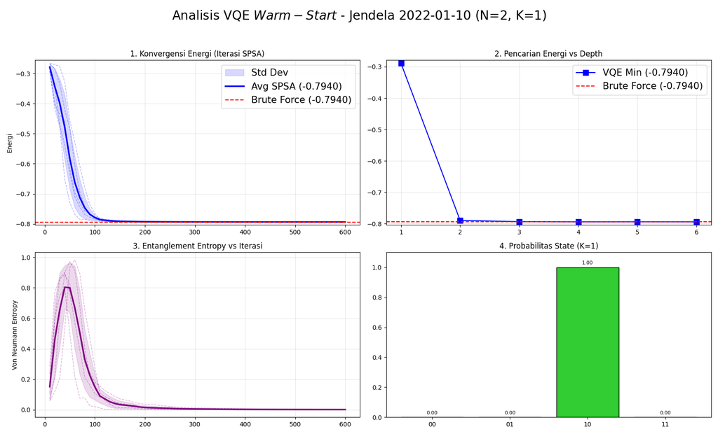

- Probabilitas runtuh di satu *state* dominan
- Solusi telah konvergen ke titik minimum energi global

## Analisis Entropi: Barren Plateau (Entropi Tinggi)

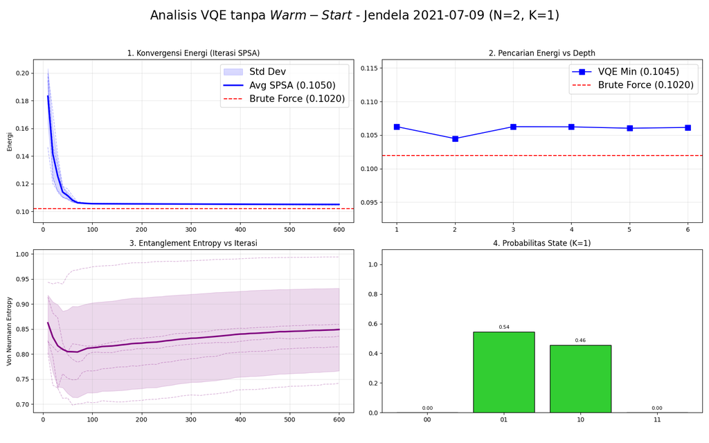